# Iowa Liquor Sales

The Iowa Department of Commerce requires that every store that sells alcohol in bottled form for off-the-premises consumption must hold a class "E" liquor license (an arrangement typical of most of the state alcohol regulatory bodies). All alcoholic sales made by stores registered thusly with the Iowa Department of Commerce are logged in the Commerce department system, which is in turn published as open data by the State of Iowa.

Data Source : https://console.cloud.google.com/marketplace/product/iowa-department-of-commerce/iowa-liquor-sales?project=fiery-province-334423

# Introduction

# Goal

Using Time Series Analysis to forecasting sales

Time series analysis comprises methods for analyzing time series data in order to extract meaningful statistics and other characteristics of the data. Time series forecasting is the use of a model to predict future values based on previously observed values.

```python
import numpy as np
import pandas as pd
import matplotlib.pyplot as plt
import seaborn as sns
%matplotlib inline

import plotly.express as px
import plotly as py
import plotly.graph_objs as go
from plotly.offline import init_notebook_mode, iplot

from statsmodels.tsa.seasonal import seasonal_decompose
from statsmodels.graphics.tsaplots import plot_acf
from statsmodels.tsa.arima_model import ARIMA

#pip install progressbar
from progressbar import *

from sklearn.preprocessing import LabelEncoder

from math import sqrt

import plotly.graph_objects as go
import plotly.express as px
import plotly as py

import matplotlib.pyplot as plt

#pip install datetime
from datetime import datetime as dt


#graph design
#pip install dash
import dash
import dash_core_components as dcc
import dash_html_components as html
from dash.dependencies import Input, Output
import plotly.graph_objects as go
```

```python
import warnings
import itertools
import numpy as np
import matplotlib.pyplot as plt

warnings.filterwarnings("ignore")
plt.style.use('fivethirtyeight')

import pandas as pd
import statsmodels.api as sm
import matplotlib

matplotlib.rcParams['axes.labelsize'] = 14
matplotlib.rcParams['xtick.labelsize'] = 12
matplotlib.rcParams['ytick.labelsize'] = 12
matplotlib.rcParams['text.color'] = 'k'
```

There are several categories in the Iowa Liquor Retail Sales, I started from time series analysis and forecasting for whiskies (category_group = 101) sales.

#### ----Load data----

We have a 4 years whiskies sales data.

```python
df_train = pd.read_excel("iowa_sale.xls")
df_train = df_train.loc[df_train['category'] == '101']

#Convert country name to uppercase
df_train['county'] = df_train['county'].apply(lambda x: x.upper())
```

### Visualizing Whiskies Sales Time Series Data

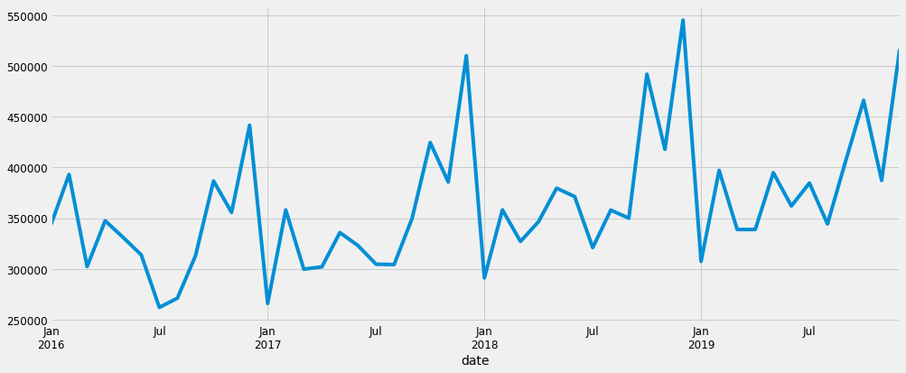

```python
y.plot(figsize=(15, 6))
plt.show()
```

Some distinguishable patterns appear when we plot the data. The time-series has seasonality pattern, such as sales are always low at the beginning of the year and high at the end of the year. There is always an upward trend within any single year with a couple of low months in the mid of the year. We can also visualize our data using a method called time-series decomposition that allows us to decompose our time series into three distinct components: trend, seasonality, and noise.

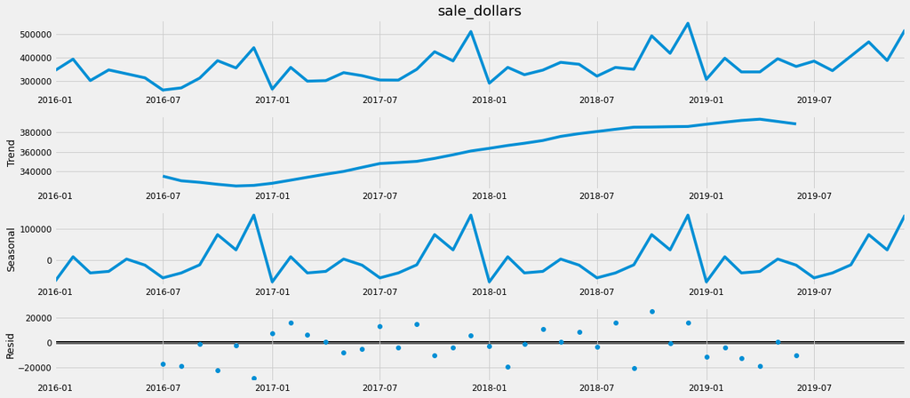

```python
from pylab import rcParams
rcParams['figure.figsize'] = 18, 8
decomposition = sm.tsa.seasonal_decompose(y, model='additive')
fig = decomposition.plot()
plt.show()
```

### Time series forecasting with ARIMA

We are going to apply one of the most commonly used method for time-series forecasting, known as ARIMA, which stands for Autoregressive Integrated Moving Average. ARIMA models are denoted with the notation ARIMA(p, d, q). These three parameters account for seasonality, trend, and noise in data:

```python
p = d = q = range(0, 2)
pdq = list(itertools.product(p, d, q))
seasonal_pdq = [(x[0], x[1], x[2], 12) for x in list(itertools.product(p, d, q))]
print('Examples of parameter combinations for Seasonal ARIMA...')
print('SARIMAX: {} x {}'.format(pdq[1], seasonal_pdq[1]))
print('SARIMAX: {} x {}'.format(pdq[1], seasonal_pdq[2]))
print('SARIMAX: {} x {}'.format(pdq[2], seasonal_pdq[3]))
print('SARIMAX: {} x {}'.format(pdq[2], seasonal_pdq[4]))
```

```
Examples of parameter combinations for Seasonal ARIMA...
SARIMAX: (0, 0, 1) x (0, 0, 1, 12)
SARIMAX: (0, 0, 1) x (0, 1, 0, 12)
SARIMAX: (0, 1, 0) x (0, 1, 1, 12)
SARIMAX: (0, 1, 0) x (1, 0, 0, 12)
```

```python
for param in pdq:
    for param_seasonal in seasonal_pdq:
        try:
            mod = sm.tsa.statespace.SARIMAX(y,order=param,seasonal_order=param_seasonal
                                            ,enforce_stationarity=False
                                            ,enforce_invertibility=False)
            results = mod.fit()
            print('ARIMA{}x{}12 - AIC:{}'.format(param,param_seasonal,results.aic))
        except:
            continue
```

```
ARIMA(0, 0, 0)x(0, 0, 0, 12)12 - AIC:1340.3709122939902
ARIMA(0, 0, 0)x(0, 0, 1, 12)12 - AIC:1359106.9452749658
ARIMA(0, 0, 0)x(0, 1, 0, 12)12 - AIC:835.6677135431349
ARIMA(0, 0, 0)x(0, 1, 1, 12)12 - AIC:551.4448049659326
ARIMA(0, 0, 0)x(1, 0, 0, 12)12 - AIC:858.3928799968005
ARIMA(0, 0, 0)x(1, 0, 1, 12)12 - AIC:1286518.9525891421
ARIMA(0, 0, 0)x(1, 1, 0, 12)12 - AIC:574.4840873024367
ARIMA(0, 0, 0)x(1, 1, 1, 12)12 - AIC:545.647096160411
ARIMA(0, 0, 1)x(0, 0, 0, 12)12 - AIC:1287.0339249034473
ARIMA(0, 0, 1)x(0, 0, 1, 12)12 - AIC:1027710.6398480405
ARIMA(0, 0, 1)x(0, 1, 0, 12)12 - AIC:809.9584683486598
ARIMA(0, 0, 1)x(0, 1, 1, 12)12 - AIC:529.3612609184377
ARIMA(0, 0, 1)x(1, 0, 0, 12)12 - AIC:995.5849532512582
ARIMA(0, 0, 1)x(1, 0, 1, 12)12 - AIC:995425.999842701
ARIMA(0, 0, 1)x(1, 1, 0, 12)12 - AIC:575.0289038192052
ARIMA(0, 0, 1)x(1, 1, 1, 12)12 - AIC:525.0104941333868
ARIMA(0, 1, 0)x(0, 0, 0, 12)12 - AIC:1172.758115841812
ARIMA(0, 1, 0)x(0, 0, 1, 12)12 - AIC:63002.92648506286
ARIMA(0, 1, 0)x(0, 1, 0, 12)12 - AIC:817.2520169461025
ARIMA(0, 1, 0)x(0, 1, 1, 12)12 - AIC:532.3025662760934
ARIMA(0, 1, 0)x(1, 0, 0, 12)12 - AIC:841.5858878061824
ARIMA(0, 1, 0)x(1, 0, 1, 12)12 - AIC:32120.90599222502
ARIMA(0, 1, 0)x(1, 1, 0, 12)12 - AIC:549.192438034076
ARIMA(0, 1, 0)x(1, 1, 1, 12)12 - AIC:526.2708584694726
ARIMA(0, 1, 1)x(0, 0, 0, 12)12 - AIC:1127.6765197365498
ARIMA(0, 1, 1)x(0, 0, 1, 12)12 - AIC:52386.437684413875
ARIMA(0, 1, 1)x(0, 1, 0, 12)12 - AIC:779.7638603980263
ARIMA(0, 1, 1)x(0, 1, 1, 12)12 - AIC:497.3729126883616
ARIMA(0, 1, 1)x(1, 0, 0, 12)12 - AIC:861.1056766196267
ARIMA(0, 1, 1)x(1, 0, 1, 12)12 - AIC:22962.382488227006
ARIMA(0, 1, 1)x(1, 1, 0, 12)12 - AIC:545.2469244778547
ARIMA(0, 1, 1)x(1, 1, 1, 12)12 - AIC:494.66554268740936
ARIMA(1, 0, 0)x(0, 0, 0, 12)12 - AIC:1199.3954240014696
ARIMA(1, 0, 0)x(0, 0, 1, 12)12 - AIC:63414.20929737532
ARIMA(1, 0, 0)x(0, 1, 0, 12)12 - AIC:828.6177397782125
ARIMA(1, 0, 0)x(0, 1, 1, 12)12 - AIC:550.684086877178
ARIMA(1, 0, 0)x(1, 0, 0, 12)12 - AIC:865.9447350102647
ARIMA(1, 0, 0)x(1, 0, 1, 12)12 - AIC:34186.117403799566
ARIMA(1, 0, 0)x(1, 1, 0, 12)12 - AIC:547.6939567482991
ARIMA(1, 0, 0)x(1, 1, 1, 12)12 - AIC:545.8366458282711
```

[output cut: 9 more lines]

```
ARIMA(1, 1, 0)x(0, 0, 1, 12)12 - AIC:42847.327128466306
ARIMA(1, 1, 0)x(0, 1, 0, 12)12 - AIC:798.6811331550467
ARIMA(1, 1, 0)x(0, 1, 1, 12)12 - AIC:515.8622418711199
ARIMA(1, 1, 0)x(1, 0, 0, 12)12 - AIC:825.9175393618978
ARIMA(1, 1, 0)x(1, 0, 1, 12)12 - AIC:27903.634928326646
ARIMA(1, 1, 0)x(1, 1, 0, 12)12 - AIC:514.0282861082587
ARIMA(1, 1, 0)x(1, 1, 1, 12)12 - AIC:515.1449895554501
ARIMA(1, 1, 1)x(0, 0, 0, 12)12 - AIC:1126.7309193512403
ARIMA(1, 1, 1)x(0, 0, 1, 12)12 - AIC:39098.87768141408
ARIMA(1, 1, 1)x(0, 1, 0, 12)12 - AIC:773.572314636845
ARIMA(1, 1, 1)x(0, 1, 1, 12)12 - AIC:494.80511455879764
ARIMA(1, 1, 1)x(1, 0, 0, 12)12 - AIC:828.3322193351363
ARIMA(1, 1, 1)x(1, 0, 1, 12)12 - AIC:6946.123865094998
ARIMA(1, 1, 1)x(1, 1, 0, 12)12 - AIC:514.3671113291532
ARIMA(1, 1, 1)x(1, 1, 1, 12)12 - AIC:490.80223757803316
```

### Fitting the ARIMA model

```python
mod = sm.tsa.statespace.SARIMAX(y,
                                order=(1, 1, 1),
                                seasonal_order=(1, 1, 0, 12),
                                enforce_stationarity=False,
                                enforce_invertibility=False)
results = mod.fit()
print(results.summary().tables[1])
```

```
==============================================================================
                 coef    std err          z      P>|z|      [0.025      0.975]
------------------------------------------------------------------------------
ar.L1         -0.0349      0.274     -0.127      0.899      -0.571       0.502
ma.L1         -0.1444      0.283     -0.510      0.610      -0.699       0.410
ar.S.L12      -0.0015      0.037     -0.042      0.967      -0.074       0.071
sigma2      7.605e+08   3.21e-10   2.37e+18      0.000    7.61e+08    7.61e+08
==============================================================================
```

Run model diagnostics to investigate any unusual behavior.

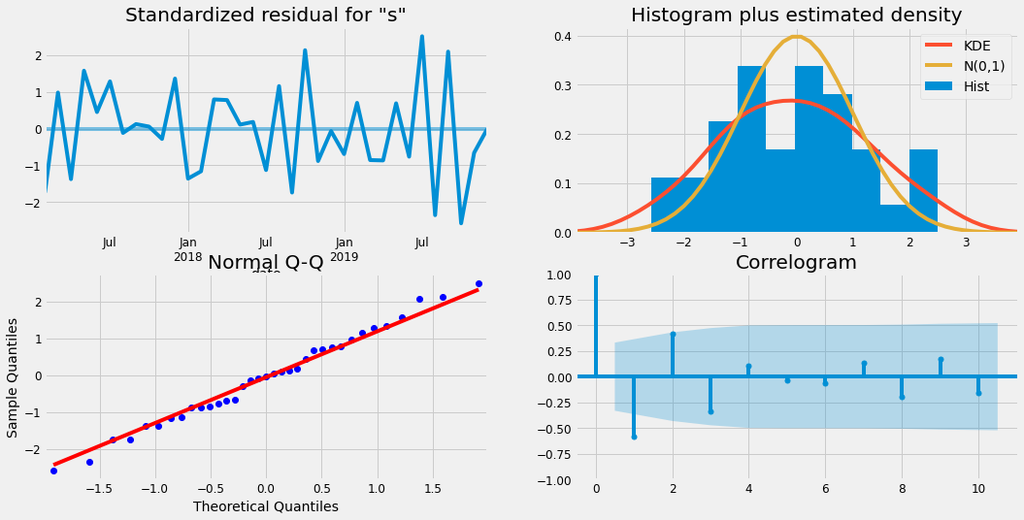

```python
results.plot_diagnostics(figsize = (16,8))
plt.show()
```

It is not perfect, however, our model diagnostics suggests that the model residuals are near normally distributed.

### Validating forecasts

To help us understand the accuracy of our forecasts, we compare predicted sales to real sales of the time series, and we set forecasts to start at 2019–01–01 to the end of the data.

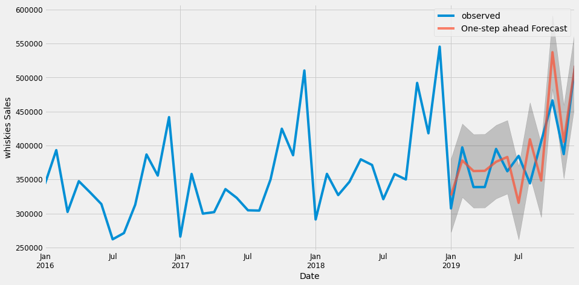

```python
pred = results.get_prediction(start=pd.to_datetime('2019-01-01'), dynamic=False)
pred_ci = pred.conf_int()
ax = y['2015':].plot(label='observed')
pred.predicted_mean.plot(ax=ax, label='One-step ahead Forecast', alpha=.7, figsize=(14, 7))
ax.fill_between(pred_ci.index,
                pred_ci.iloc[:, 0],
                pred_ci.iloc[:, 1], color='k', alpha=.2)
ax.set_xlabel('Date')
ax.set_ylabel('whiskies Sales')
plt.legend()
plt.show()
```

The line plot is showing the observed values compared to the rolling forecast predictions. Overall, our forecasts align with the true values very well, showing an upward trend starts from the beginning of the year and captured the seasonality toward the end of the year.

```python
y_forecasted = pred.predicted_mean
y_truth = y['2019-01-01':]
mse = ((y_forecasted - y_truth) ** 2).mean()
print('The Mean Squared Error of our forecasts is {}'.format(round(mse, 2)))
```

```
The Mean Squared Error of our forecasts is 1691902713.18
```

```python
print('The Root Mean Squared Error of our forecasts is {}'.format(round(np.sqrt(mse), 2)))
```

```
The Root Mean Squared Error of our forecasts is 41132.75
```

In statistics, the mean squared error (MSE) of an estimator measures the average of the squares of the errors — that is, the average squared difference between the estimated values and what is estimated. The MSE is a measure of the quality of an estimator — it is always non-negative, and the smaller the MSE, the closer we are to finding the line of best fit.

### Producing and visualizing forecasts

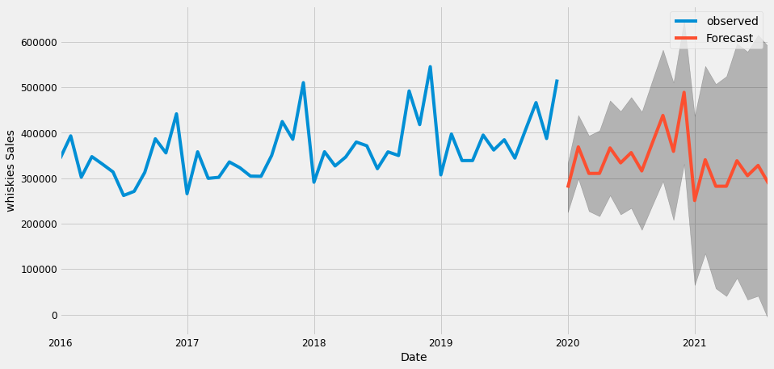

```python
pred_uc = results.get_forecast(steps=20)
pred_ci = pred_uc.conf_int()
ax = y.plot(label='observed', figsize=(14, 7))
pred_uc.predicted_mean.plot(ax=ax, label='Forecast')
ax.fill_between(pred_ci.index,
                pred_ci.iloc[:, 0],
                pred_ci.iloc[:, 1], color='k', alpha=.25)
ax.set_xlabel('Date')
ax.set_ylabel('whiskies Sales')
plt.legend()
plt.show()
```

The model clearly captured whiskies sales seasonality. As we forecast further out into the future, it is natural for us to become less confident in our values. This is reflected by the confidence intervals generated by our model, which grow larger as we move further out into the future.

Thanks for reading!!! 😊 🍀